# Simulations of Time Series Data

Andira Putri

#### Generating Time Series Data in R

The function `ts()` can convert a numeric vector into a time series object in R. The syntax is `ts(vectorname, start=, end=, frequency=)`, where start/end are the first/last time points, and frequency is the number of observations per unit in time. `frequency=1` means yearly, `frequency=12` means monthly, etc. Let’s generate a time series data set here:

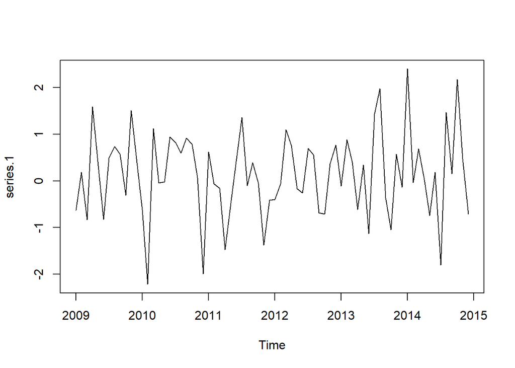

```r
set.seed(1)
#randomly generate vector of length 72
vector=rnorm(72,0,1)
#generate time series spanning 6 years
#6 years --> 72 months, frequency=12 puts time series in terms of months
series.1=ts(vector,start=c(2009,1),end=c(2014,12),frequency=12)
plot.ts(series.1)
```

We see that the data revolves around the mean 0, and there is no random walk.

#### Lag

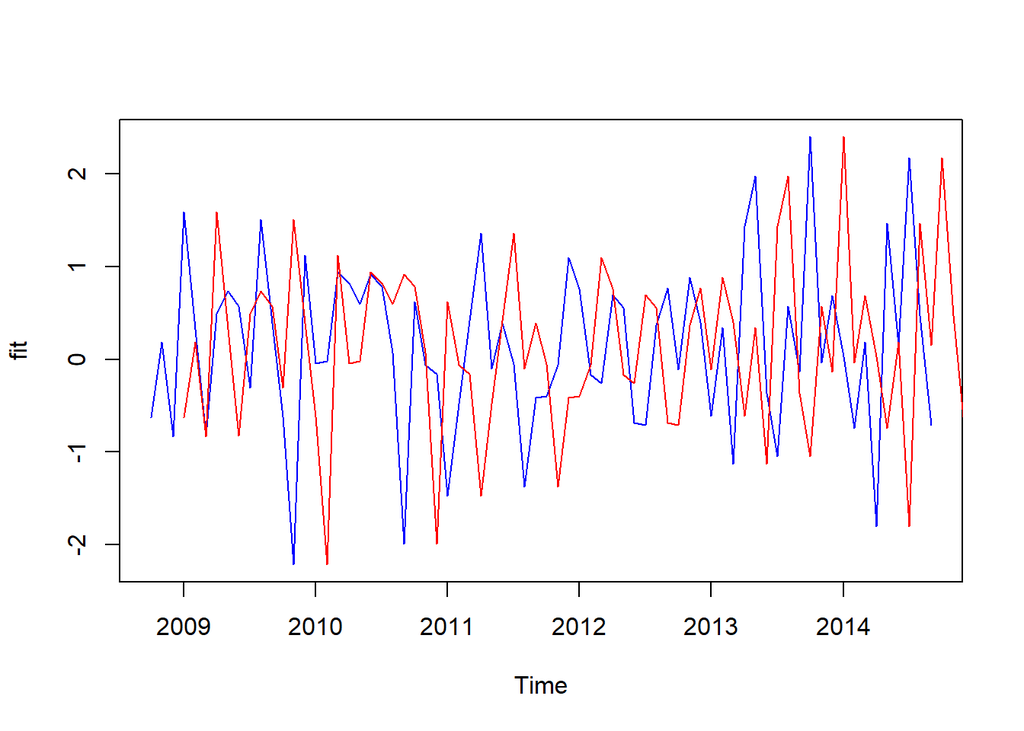

```r
fit=lag(series.1,3)
plot.ts(fit,col="blue")
lines(series.1,col="red")
library(forecast)
```

#### Autocorrelation

Autocorrelation functions (`acf`) are useful for measuring the linear predictability of the series at time t ($x_t$) using only the variable ($x_s$). The function is given by:

$p(s,t)=\frac{\gamma(s,t)}{\sqrt{\gamma(s,s)\gamma(t,t)}}$, where $\gamma(s,t)=cov(x_s,x_t)$ and $\gamma(t,t)=cov(x_t,x_t)=var(x_t)$. Thank you Math Stat.

Another forumalation is given measurements $Y_1, Y_2, ..., Y_N$ at time $X_1, X_2, ..., X_N$, the lag k autocorrelation function is defined as:

$r_k=\frac{\sum_{i=1}^{N-k}(Y_{i}-\bar{Y})(Y_{i+k}-\bar{Y})}{\sum_{i=1}^{N}(Y_{i}-\bar{Y})^{2}}$

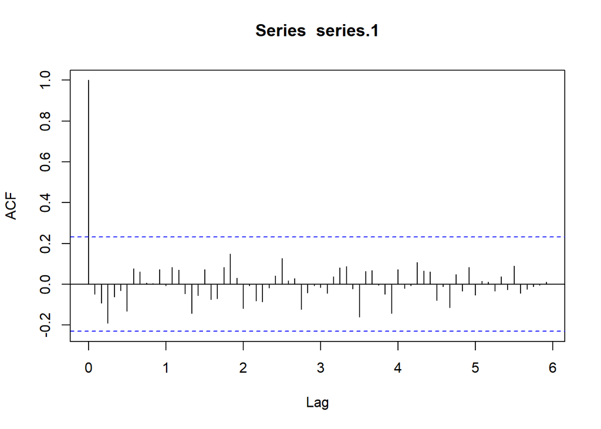

```r
library(forecast)
#generate correlogram
acf=acf(series.1,500)
```

All correlograms start with an autocorrelation of 1; this is because when t=0, we are comparing the time series with itself. Periodicity is a good indicator of frequency in the time series data. For example, if each peak in a correlogram occurs when t is a multiple of 7, it is likely that the data is in terms of weeks and it’s not just a coincidence.

When using the entirety of time series data, interpreting correlograms might not be easy. Partial autocorrelation functions (`pacf`) controls the values of the time series at shorter lags. This process removes the interference and resonance from multiple cycles and gives a more clear periodicity.

Great reads!

- https://www.alanzucconi.com/2016/06/06/autocorrelation-function/#part2
- https://www.itl.nist.gov/div898/handbook/eda/section3/eda35c.htm